# ScoreCard

```python
from typing import *

import pandas as pd
import seaborn as sns
import matplotlib.pyplot as plt
import numpy as np
from sklearn.model_selection import train_test_split
from sklearn.linear_model import LogisticRegression
from sklearn.metrics import accuracy_score, confusion_matrix
```

## 1. Tiền xử lý dữ liệu

**Nghiên cứu dataset**

> - Có bao nhiêu hàng và cột? Mỗi hàng và cột đại diện cho thông tin gì?
> - Đặc trưng của mỗi hàng và cột: kiểu dữ liệu, các thông tin thống kê cơ bản.
> - Số lượng giá trị bị thiếu trong mỗi hàng và cột

```python
data = pd.read_csv('http://www.creditriskanalytics.net/uploads/1/9/5/1/19511601/hmeq.csv', header=0, sep=',')
```

```python
data.info()
```

```
<class 'pandas.core.frame.DataFrame'>
RangeIndex: 5960 entries, 0 to 5959
Data columns (total 13 columns):
 #   Column   Non-Null Count  Dtype
---  ------   --------------  -----
 0   BAD      5960 non-null   int64
 1   LOAN     5960 non-null   int64
 2   MORTDUE  5442 non-null   float64
 3   VALUE    5848 non-null   float64
 4   REASON   5708 non-null   object
 5   JOB      5681 non-null   object
 6   YOJ      5445 non-null   float64
 7   DEROG    5252 non-null   float64
 8   DELINQ   5380 non-null   float64
 9   CLAGE    5652 non-null   float64
 10  NINQ     5450 non-null   float64
 11  CLNO     5738 non-null   float64
 12  DEBTINC  4693 non-null   float64
dtypes: float64(9), int64(2), object(2)
memory usage: 605.4+ KB
```

**Mô tả dữ liệu**

- BAD: 1 = Hồ sơ vay là vi phạm hoặc mất khả năng trả nợ; 0 = hồ sơ vay đã và đang trả nợ.
- LOAN: Số tiền yêu cầu cho vay.
- MORTDUE: Số tiền đến hạn của khoản thế chấp hiện có.
- VALUE: Giá trị tài sản hiện tại.
- REASON: DebtCon = nợ hợp nhất; HomeImp = cải thiện nhà.
- JOB: Thể loại nghề nghiệp.
- YOJ: Số năm kinh nghiệm trong nghề nghiệp hiện tại.
- DEROG: Số lượng báo cáo không tín nhiệm.
- DELINQ: Số hạn mức tín dụng quá hạn.
- CLAGE: Tuổi của hạn mức tín dụng cũ nhất tính theo tháng.
- NINQ: Số câu hỏi tín dụng gần đây.
- CLNO: Số lượng hạn mức tín dụng.
- DEBTINC: Tỷ lệ nợ trên thu nhập.

```python
data.head()
```

|  | BAD | LOAN | MORTDUE | VALUE | REASON | JOB | YOJ | DEROG | DELINQ | CLAGE | NINQ | CLNO | DEBTINC |
| --- | --- | --- | --- | --- | --- | --- | --- | --- | --- | --- | --- | --- | --- |
| 0 | 1 | 1100 | 25860.0 | 39025.0 | HomeImp | Other | 10.5 | 0.0 | 0.0 | 94.366667 | 1.0 | 9.0 | NaN |
| 1 | 1 | 1300 | 70053.0 | 68400.0 | HomeImp | Other | 7.0 | 0.0 | 2.0 | 121.833333 | 0.0 | 14.0 | NaN |
| 2 | 1 | 1500 | 13500.0 | 16700.0 | HomeImp | Other | 4.0 | 0.0 | 0.0 | 149.466667 | 1.0 | 10.0 | NaN |
| 3 | 1 | 1500 | NaN | NaN | NaN | NaN | NaN | NaN | NaN | NaN | NaN | NaN | NaN |
| 4 | 0 | 1700 | 97800.0 | 112000.0 | HomeImp | Office | 3.0 | 0.0 | 0.0 | 93.333333 | 0.0 | 14.0 | NaN |

**Vẽ biểu đồ phân tích dữ liệu**

- **Đối với dữ liệu numeric**
  > - Bỏ qua các giá trị NaN
  > - Vẽ biểu đồ thể hiện dữ liệu theo các bins và số lượng trong mỗi bins đó.
- **Đối với dữ liệu category**
  > - Thay các giá trị thiếu bằng Missing value
  > - Vẽ biểu đồ thể hiện số lượng mỗi category

```python
# Biểu đồ histogram
def _plot_hist_subplot(x, fieldname, bins = 10, use_kde = True):
  x = x.dropna()
  xlabel = '{} bins tickers'.format(fieldname)
  ylabel = 'Count obs in {} each bin'.format(fieldname)
  title = 'histogram plot of {} with {} bins'.format(fieldname, bins)
  ax = sns.distplot(x, bins = bins, kde = use_kde)
  ax.set_xlabel(xlabel)
  ax.set_ylabel(ylabel)
  ax.set_title(title)
  return ax
```

```python
# Biểu đồ barchart
def _plot_barchart_subplot(x, fieldname):
  xlabel = 'Group of {}'.format(fieldname)
  ylabel = 'Count obs in {} each bin'.format(fieldname)
  title = 'Barchart plot of {}'.format(fieldname)
  x = x.fillna('Missing')
  df_summary = x.value_counts(dropna = False)
  y_values = df_summary.values
  x_index = df_summary.index
  ax = sns.barplot(x = x_index, y = y_values, order = x_index)
  # Tạo vòng for lấy tọa độ đỉnh trên cùng của biểu đồ và thêm label thông qua annotate.
  labels = list(set(x))
  for label, p in zip(y_values, ax.patches):
    ax.annotate(label, (p.get_x()+0.25, p.get_height()+0.15))
  plt.xlabel(xlabel)
  plt.ylabel(ylabel)
  plt.title(title)
  return ax
```

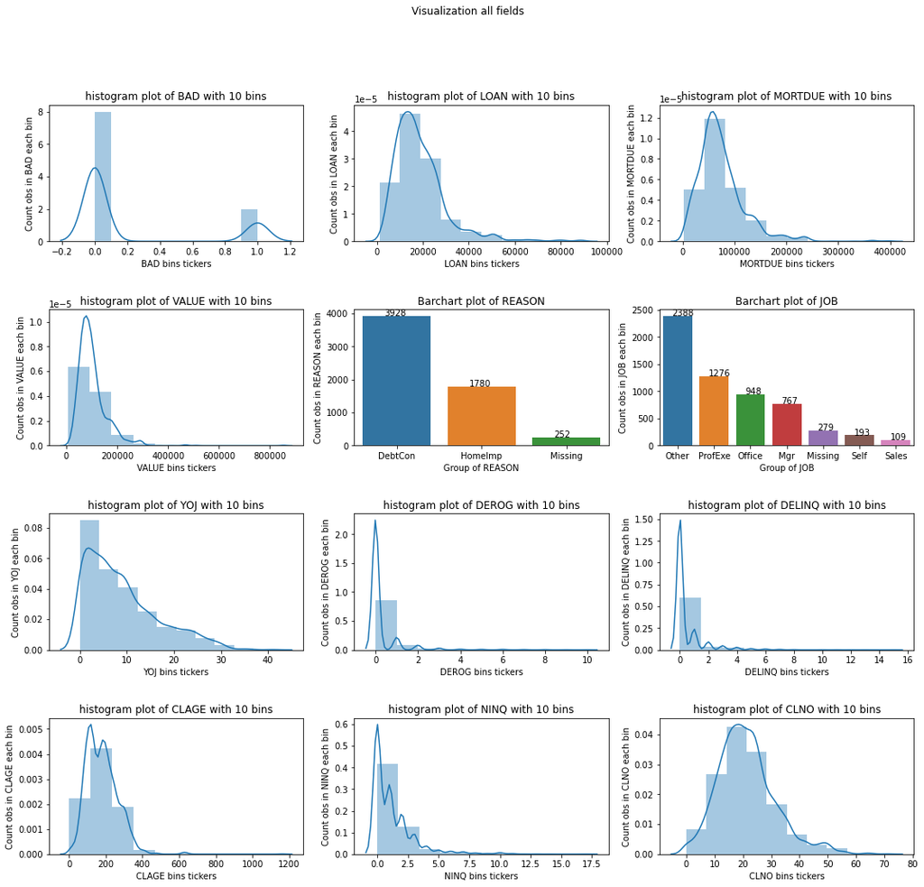

```python
# Khởi tạo figure cho đồ thị (Kích thước W*H = 16x12) và cách nhau là 0.2 giữa các đồ thị
fig = plt.figure(figsize=(18, 16))
fig.subplots_adjust(hspace=0.5, wspace=0.2)
# Tạo vòng for check định dạng của biến và visualize
for i, (fieldname, dtype) in enumerate(zip(data.columns, data.dtypes.values)):
  if i <= 11:
    ax_i = fig.add_subplot(4, 3, i+1)
    if dtype in ['float64', 'int64']:
      ax_i = _plot_hist_subplot(data[fieldname], fieldname=fieldname)
    else:
      ax_i = _plot_barchart_subplot(data[fieldname], fieldname=fieldname)

fig.suptitle('Visualization all fields')
plt.show()
```

**Thay thế các giá trị thiếu trong các bảng dữ liệu (bằng giá trị trung bình với các biến numeric và Missing với các dữ liệu category**

```python
columns_num = data.select_dtypes(['float', 'int']).columns
data[columns_num] = data[columns_num].apply(lambda x: x.fillna(x.mean()), axis=0)
```

```python
column_obj = data.select_dtypes(['object']).columns
data[column_obj] = data[column_obj].apply(lambda x: x.fillna('Missing'), axis=0)
```

## 2. Trích chọn đặc trưng

**Chia các cột dữ liệu thành các bins**

- Chia thông qua số lượng bins
- Chia thông qua ngưỡng cho sẵn
- Chia theo các class của dữ liệu

```python
MIN_VAL = -99999999
MAX_VAL = - MIN_VAL
def _bin_table(data, colname, n_bins=10, qcut=None):
    sub_data = data[[colname, 'BAD']]
    sub_data = sub_data.sort_values(colname)
    coltype = sub_data[colname].dtype

    if coltype in [np.float64, np.int64]:
        if qcut is not None:
            bins, thres_bin = pd.cut(sub_data[colname], bins=qcut, retbins=True)
            sub_data['bins'] = bins
        else:
            try:
                bins, thres_bin = pd.qcut(sub_data[colname], q=n_bins, retbins=True)
                thres_bin[0] = MIN_VAL
                thres_bin[-1] = MAX_VAL
                bins, thres_bin = pd.cut(sub_data[colname], bins=thres_bin, retbins=True)
                sub_data["bins"] = bins
            except:
                print('n_bins must be lower to bin interval is valid!')
                return None, None
    else:
        print("coltype is not float, int")
        sub_data["bins"] = sub_data[colname]

    df_GB = pd.pivot_table(sub_data, index=['bins'], values=['BAD'], columns=['BAD'], aggfunc={'BAD': np.size})

    df_summary = pd.DataFrame(index=df_GB.index)
    df_summary['#BAD'] = df_GB['BAD', 0]
    df_summary['#GOOD'] = df_GB['BAD', 1]
    df_summary['No_Obs'] = df_summary['#BAD'] + df_summary['#GOOD']
    if coltype in [np.float64, np.int64]:
        df_summary['Thres'] = thres_bin[1:]
    else:
        thres_bin = None

    return df_summary, thres_bin
```

```python
df_summary, thres = _bin_table(data, 'LOAN', n_bins=7)
print(df_summary)
```

```
                       #BAD  #GOOD  No_Obs       Thres
bins
(-99999999.0, 8700.0]   596    271     867      8700.0
(8700.0, 12000.0]       698    197     895     12000.0
(12000.0, 15000.0]      673    187     860     15000.0
(15000.0, 18000.0]      677    119     796     18000.0
(18000.0, 22200.0]      720    130     850     22200.0
(22200.0, 27300.0]      713    129     842     27300.0
(27300.0, 99999999.0]   694    156     850  99999999.0
```

**Tính điểm WoE và IV cho từng loại**

- Gộp các bins có số lượng quá ít
- Tính điểm WOE cho từng biến

```python
def _WoE(data_frame:pd.DataFrame, colname:str, n_bins:int=None, qcut:List[int]=None, min_obs:int=100):
    df_summary, thres = _bin_table(data_frame, colname, n_bins, qcut)
    df_summary["#BAD"] = df_summary["#BAD"].replace({0:1})

    if qcut is not None:
        exclude_index = np.where(df_summary["No_Obs"] <= min_obs)
        if len(exclude_index) > 0:
            new_thres = np.delete(thres, exclude_index)
            df_summary, thres = _bin_table(data, colname, qcut=new_thres)

    df_summary["%GOOD"] = df_summary["#GOOD"] / df_summary["#GOOD"].sum()
    df_summary["%BAD"] = df_summary["#BAD"] / df_summary["#BAD"].sum()
    df_summary["WOE"] = np.log(df_summary["%GOOD"] / df_summary["%BAD"])
    df_summary["IV_BIN"] = (df_summary["%GOOD"] - df_summary["%BAD"]) * df_summary["WOE"]
    df_summary["COLUMN"] = colname

    IV = df_summary["IV_BIN"].sum()
    print("IV of column {} is {}".format(colname, IV))

    return df_summary, IV, thres
```

```python
df_summary, IV, thres = _WoE(data, "DEBTINC", 7)
```

```
IV of column DEBTINC is 1.3795573580411762
```

```python
# Đối với các biến numeric
WOE_features = {}
n_bins_numeric = {"LOAN": 10, "MORTDUE": 10, "VALUE": 10, "YOJ": 10, "CLAGE": 10, "CLNO": 10, "DEBTINC": 7}

for colname in n_bins_numeric:
    df_summary, IV, _ = _WoE(data, colname, n_bins_numeric[colname])
    WOE_features[colname] = {"table": df_summary, "IV": IV}

for colname in ["DEROG", "DELINQ", "NINQ"]:
    df_summary, IV, _ = _WoE(data, colname, qcut=[MIN_VAL, 1, MAX_VAL])
    WOE_features[colname] = {"table": df_summary, "IV": IV}

for colname in ["REASON", "JOB"]:
    df_summary, IV, _ = _WoE(data, colname, qcut=[MIN_VAL, 1, MAX_VAL])
    WOE_features[colname] = {"table": df_summary, "IV": IV}
```

```
IV of column LOAN is 0.1601563338988017
IV of column MORTDUE is 0.05131351983314017
IV of column VALUE is 0.14188912125986042
IV of column YOJ is 0.06714693781095009
IV of column CLAGE is 0.22171042878294653
IV of column CLNO is 0.06043698467606807
IV of column DEBTINC is 1.3795573580411762
IV of column DEROG is 0.25544310740061354
IV of column DELINQ is 0.41067752435125704
IV of column NINQ is 0.06965935231976197
coltype is not float, int
coltype is not float, int
IV of column REASON is 0.008618460238864025
coltype is not float, int
coltype is not float, int
IV of column JOB is 0.1237305657142077
```

**Xếp loại mức độ quan trọng của biến thông quá giá trị IV**

```python
columns = []
IVs = []

for colname in WOE_features:
    columns.append(colname)
    IVs.append(WOE_features[colname]["IV"])
df_woe = pd.DataFrame({"column": columns, "IV": IVs})

def _rank_column(iv):
    if iv < 0.02:
        return "Useless"
    elif iv <= 0.1:
        return "Weak"
    elif iv <=0.3:
        return "Medium"
    elif iv <= 0.5:
        return "Strong"
    else:
        return "Suspicious"

df_woe["rank"] = df_woe["IV"].apply(lambda x: _rank_column(x))
df_woe.sort_values("IV", ascending=False)
```

|  | column | IV | rank |
| --- | --- | --- | --- |
| 6 | DEBTINC | 1.379557 | Suspicious |
| 8 | DELINQ | 0.410678 | Strong |
| 7 | DEROG | 0.255443 | Medium |
| 4 | CLAGE | 0.221710 | Medium |
| 0 | LOAN | 0.160156 | Medium |
| 2 | VALUE | 0.141889 | Medium |
| 11 | JOB | 0.123731 | Medium |
| 9 | NINQ | 0.069659 | Weak |
| 3 | YOJ | 0.067147 | Weak |
| 5 | CLNO | 0.060437 | Weak |
| 1 | MORTDUE | 0.051314 | Weak |
| 10 | REASON | 0.008618 | Useless |

**Biểu diễn dữ liệu ở dataframe ban đầu về giá trị WoE của bins đó**

```python
for colname in WOE_features:
    bins = list(WOE_features[colname]['table']["WOE"].index)
    woe = list(WOE_features[colname]['table']["WOE"])

    d = dict(zip(bins, woe))

    col_woe = colname + "_woe"
    data[col_woe] = data[colname].map(d)

print(data)
```

```
      BAD   LOAN     MORTDUE          VALUE   REASON      JOB        YOJ  \
0       1   1100  25860.0000   39025.000000  HomeImp    Other  10.500000
1       1   1300  70053.0000   68400.000000  HomeImp    Other   7.000000
2       1   1500  13500.0000   16700.000000  HomeImp    Other   4.000000
3       1   1500  73760.8172  101776.048741  Missing  Missing   8.922268
4       0   1700  97800.0000  112000.000000  HomeImp   Office   3.000000
...   ...    ...         ...            ...      ...      ...        ...
5955    0  88900  57264.0000   90185.000000  DebtCon    Other  16.000000
5956    0  89000  54576.0000   92937.000000  DebtCon    Other  16.000000
5957    0  89200  54045.0000   92924.000000  DebtCon    Other  15.000000
5958    0  89800  50370.0000   91861.000000  DebtCon    Other  14.000000
5959    0  89900  48811.0000   88934.000000  DebtCon    Other  15.000000

        DEROG    DELINQ       CLAGE  ...  VALUE_woe   YOJ_woe  CLAGE_woe  \
0     0.00000  0.000000   94.366667  ...   0.630114  0.094209   0.386975
```

[output cut: 38 more lines]

```python
X = data.filter(like="_woe", axis=1)
y = data["BAD"]
```

```python
x_train, x_test, y_train, y_test = train_test_split(X, y, test_size=0.2)\

print("x_train shape", x_train.shape)
print("y_train shape", y_train.shape)
print("x_test shape", x_test.shape)
print("y_test shape", y_test.shape)
```

```
x_train shape (4768, 12)
y_train shape (4768,)
x_test shape (1192, 12)
y_test shape (1192,)
```

## 3. Build model

```python
model = LogisticRegression(solver='lbfgs', max_iter=1000)
model.fit(x_train, y_train)

y_pred = model.predict(x_test)

print("accuracy_score on test", accuracy_score(y_pred, y_test))
print("confusion matrix is ", confusion_matrix(y_pred, y_test))
```

```
accuracy_score on test 0.8649328859060402
confusion matrix is  [[920 119]
 [ 42 111]]
```

**Đánh giá kết quả mô hình**

- Đường cong precision/ recall

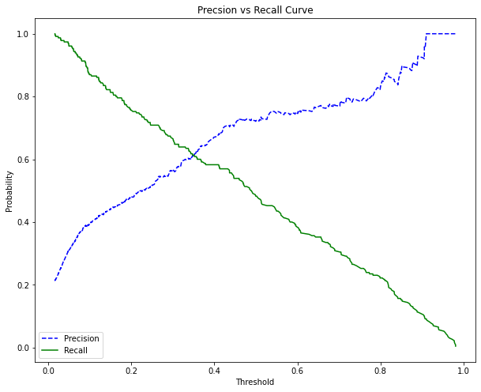

```python
from sklearn.metrics import precision_recall_curve
y_prob = model.predict_proba(x_test)[:, 1]
precision, recall, thres = precision_recall_curve(y_test, y_prob)

def _plot_prec_rec_curve(prec, rec, thres):
    plt.figure(figsize = (10, 8))
    plt.plot(thres, prec[:-1], 'b--', label = 'Precision')
    plt.plot(thres, rec[:-1], 'g-', label = 'Recall')
    plt.xlabel('Threshold')
    plt.ylabel('Probability')
    plt.title('Precsion vs Recall Curve')
    plt.legend()

_plot_prec_rec_curve(precision, recall, thres)
```

- Đường cong ROC trên tập test

Chỉ số AUC (area under curve) đo lường phần diện tích nằm dưới đường cong ROC cho biết khả năng phân loại của các hợp đồng GOOD/BAD của mô hình hồi qui logistic là mạnh hay yếu. AUC ∈ [0,1], giá trị của nó càng lớn thì mô hình càng tốt.

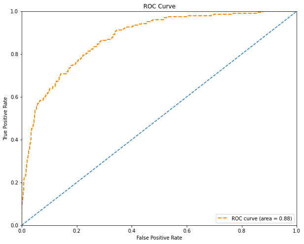

```python
from sklearn.metrics import roc_curve, auc

fpr, tpr, thres = roc_curve(y_test, y_prob)
roc_auc = auc(fpr, tpr)

def _plot_roc_curve(fpr, tpr, thres, auc):
    plt.figure(figsize = (10, 8))
    plt.plot(fpr, tpr, 'b-', color='darkorange', lw=2, linestyle='--', label='ROC curve (area = %0.2f)'%auc)
    plt.plot([0, 1], [0, 1], '--')
    plt.axis([0, 1, 0, 1])
    plt.xlabel('False Positive Rate')
    plt.ylabel('True Positive Rate')
    plt.legend(loc='lower right')
    plt.title('ROC Curve')

_plot_roc_curve(fpr, tpr, thres, roc_auc)
```

## 4. Dự đoán điểm của hồ sơ mới

[figure not shown]

**Các bước thực hiện như sau:**

- **Tính điểm credit score cho mỗi feature để đưa điểm xác suất về điểm tín dụng theo công thức** $$\text{Score} = (\beta.\text{WOE}+\frac{\alpha}{n}).\text{Factor}+\frac{\text{Offset}}{n}$$ Trong đó:
> - $\beta$: Hệ số của biến trong phương trình hồi qui logistic.
> - $\alpha$: Hệ số chặn của phương trình hồi qui logistic.
> - $WOE$: Hệ số trọng số bằng chứng của mỗi feature.
> - $n$: Số lượng các biến của mô hình.
> - $Factor,Offset$: Là các tham số được thiết lập để tính Score.
- **Tính điểm của hồ sơ thông qua tổng điểm các feature**

**Tính điểm credit score cho mỗi feature**

Xây dựng hàm tính creditscore cho mỗi bin của biến

```python
def _CreditScore(beta, alpha, woe, n=12, odds=1/4, pdo=-50, thres_score=600):
    factor = pdo/np.log(2)
    offset = thres_score - factor*np.log(odds)
    score = (beta*woe+alpha/n)*factor+offset/n
    return score
```

Lấy giá trị alpha và beta từ model

```python
betas_dict = dict(zip(list(x_train.columns), model.coef_[0]))
alpha = model.intercept_[0]
betas_dict
```

```
{'LOAN_woe': 0.5468400450437401,
 'MORTDUE_woe': 0.6349816650118777,
 'VALUE_woe': 0.7068118984732504,
 'YOJ_woe': 0.8836182984077355,
 'CLAGE_woe': 0.8518875840476123,
 'CLNO_woe': 0.7373040030510914,
 'DEBTINC_woe': 0.9382221690060948,
 'DEROG_woe': 0.7509240822918261,
 'DELINQ_woe': 0.9659763259735575,
 'NINQ_woe': 0.5998315833991107,
 'REASON_woe': 0.7927100856663031,
 'JOB_woe': 0.8547734550976572}
```

Tính giá trị credit score cho toàn bộ các biến

```python
cols = []
features = []
woes = []
betas = []
scores = []

for col in columns:
    for feature, woe in WOE_features[col]['table']['WOE'].to_frame().iterrows():
        cols.append(col)
        # Add feature
        feature = str(feature)
        features.append(feature)
        # Add woe
        woe = woe.values[0]
        woes.append(woe)
        # Add beta
        col_woe = col+'_woe'
        beta = betas_dict[col_woe]
        betas.append(beta)
        # Add score
        score = _CreditScore(beta = beta, alpha = alpha, woe = woe, n = 12)
        scores.append(score)

df_WOE = pd.DataFrame({'Columns': cols, 'Features': features, 'WOE': woes, 'Betas':betas, 'Scores':scores})
df_WOE.head()
```

|  | Columns | Features | WOE | Betas | Scores |
| --- | --- | --- | --- | --- | --- |
| 0 | LOAN | (-99999999.0, 7600.0] | 0.898910 | 0.54684 | 14.575073 |
| 1 | LOAN | (7600.0, 10000.0] | 0.154566 | 0.54684 | 43.936569 |
| 2 | LOAN | (10000.0, 12100.0] | -0.112535 | 0.54684 | 54.472704 |
| 3 | LOAN | (12100.0, 14400.0] | -0.158318 | 0.54684 | 56.278652 |
| 4 | LOAN | (14400.0, 16300.0] | 0.162082 | 0.54684 | 43.640096 |

Tính điểm cho mỗi hồ sơ

```python
# Giả sử một hồ sơ ngẫu nhiên có các thông số như sau
test_obs = data[columns].iloc[0:1, :]
test_obs
```

|  | LOAN | MORTDUE | VALUE | YOJ | CLAGE | CLNO | DEBTINC | DEROG | DELINQ | NINQ | REASON | JOB |
| --- | --- | --- | --- | --- | --- | --- | --- | --- | --- | --- | --- | --- |
| 0 | 1100 | 25860.0 | 39025.0 | 10.5 | 94.366667 | 9.0 | 33.779915 | 0.0 | 0.0 | 1.0 | HomeImp | Other |

```python
def _search_score(obs, col):
    for inter in list(WOE_features[col]["table"].index):
        if obs[col].values[0] in inter:
            feature = str(inter)

    score = df_WOE[(df_WOE['Columns'] == col) & (df_WOE["Features"] == feature)]["Scores"].values[0]

    return score

_search_score(test_obs, "MORTDUE")
```

```
31.52892085757093
```

```python
def _total_score(obs, columns = columns):
    scores = dict()
    for col in columns:
        scores[col] = _search_score(obs, col)
        total_score = sum(scores.values())
    return scores, total_score

scores, total_score = _total_score(test_obs)
print('score for each fields: \n', scores)
print('final total score: ', total_score)
```

[output not shown]

**Suy ra hồ sơ trên là hồ sơ BAD, kiểm tra lại dữ liệu ban đầu**

```python
data.iloc[0]
```

```
BAD                    1
LOAN                1100
MORTDUE            25860
VALUE              39025
REASON           HomeImp
JOB                Other
YOJ                 10.5
DEROG                  0
DELINQ                 0
CLAGE            94.3667
NINQ                   1
CLNO                   9
DEBTINC          33.7799
LOAN_woe         0.89891
MORTDUE_woe     0.403995
VALUE_woe       0.630114
YOJ_woe        0.0942089
CLAGE_woe       0.386975
CLNO_woe        0.484269
DEBTINC_woe      1.35905
DEROG_woe      -0.139622
DELINQ_woe     -0.253851
NINQ_woe       -0.210721
REASON_woe      0.138124
JOB_woe         0.192353
Name: 0, dtype: object
```

**The end**